# Population assumptions

Published

July 29, 2024

Modified

July 25, 2024

Detail on the assumptions relating to design variables.

## Silo membership

The probability of silo membership is shown below.

Silo categories ($\pi$ denotes probability of membership)

| Silo | $\pi$ |
| --- | --- |
| early | 0.3 |
| late | 0.5 |
| chronic | 0.2 |

## Site of infection (joint)

Each silo comprises patients with either a knee or hip infection. The assumed proportion of infections for each joint and for each silo are shown below.

Site of infection ($\pi$ denotes probability of site infection conditional on silo membership)

| Silo | Joint | $\pi$ |  |
| --- | --- | --- | --- |
| early | knee | 0.4 |  |
| early | hip | 0.6 |  |
| late | knee | 0.7 |  |
| late | hip | 0.3 |  |
| chronic | knee | 0.5 |  |
| chronic | hip | 0.5 |  |

## Surgery domain

Early stage patients do not receive randomisation and are assumed to mostly receive DAIR, although they may have any form of surgery. We assume the proportion of dair, one and two-stage surgery to be 85%, 10% and 5%.

Late stage patients enter for randomised surgery and are allocated 1:1 to DAIR/revision. The clinician selects the specific type of revision (one-stage or two-stage) to be performed. For late stage infection patients randomised to dair, we assume that the preferences for dair, one and two-stage are 20%, 24% and 56%. For late stage infection patients randomised to revision, we assume that the preferences for one and two-stage are 30% and 70%.

Chronic stage patients do not receive randomisation and are assumed to receive DAIR, one-stage and two-stage based on clinician assessment. For chronic stage infection patients, we assume that the preferences for dair, one and two-stage are 20%, 20% and 60%.

## Antibiotic backbone duration domain

Entry into antibiotic backbone duration domain is dependent on the surgery that was received. Specifically, this domain only applies for patients receiving one-stage revision.

Within the antibiotic backbone duration domain, allocation is to 12 weeks vs 6 weeks duration.

Patients receiving DAIR and two-stage revision are assumed to have 12 wk duration (not randomised).

## Extended prophylaxis domain

Entry into extended prophylaxis domain is dependent on the surgery that was received. Specifically, this domain only applies for patients receiving two-stage revision.

Within the extended prophylaxis domain, allocation is to 12 weeks vs 7 days duration following the second stage of the revision.

Patients receiving DAIR and one-stage revision are assumed to not receive any extended prophylaxis.

## Randomisation into antibiotic choice domain

Entry into antibiotic choice is primarily indicated by microbiology. For simplicity, the data generating process assumes that 60% of the total sample enter into this domain at random, unrelated to risk factors, irrespective of surgery type, silo and site of infection.

## Baseline response

The baseline probability/log-odds of treatment success is assumed to vary by silo and site of infection as detailed below.

Baseline probability of treatment success by silo and site of infection

| Silo | Joint | Pr(trt success) | log-odds |
| --- | --- | --- | --- |
| early | knee | 0.65 | 0.62 |
| early | hip | 0.75 | 1.10 |
| late | knee | 0.55 | 0.20 |
| late | hip | 0.6 | 0.41 |
| chronic | knee | 0.6 | 0.41 |
| chronic | hip | 0.65 | 0.62 |

## Accrual

Accrual is assumed to follow a non-homogeneous Poisson process event times with ramp up over the first 12 months of enrolment and then enrolment of around 1.5 per day.

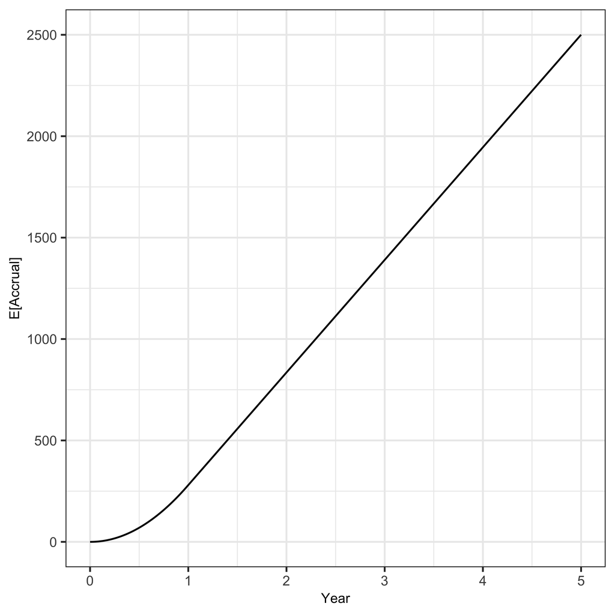

Figure 1: Expected accrual

```r
# events per day
lambda = 1.52
# ramp up over 12 months
rho = function(t) pmin(t/360, 1)

d_fig <- data.table(
  t = 0:(5 * 365),
  # expected number enrolled
  n = c(0, nhpp.mean(lambda, rho, t1 = 5 * 365, num.points = 5 * 365))
)

ggplot(d_fig, aes(x = t/365, y = n)) +
  geom_line() +
  scale_x_continuous("Year") +
  scale_y_continuous("E[Accrual]", breaks = seq(0, 2500, by = 500))
```

## Missingness

Missingness is not implemented.

## Non-differential follow-up

To avoid artifacts associated with non-differential follow-up (e.g. early vs late deaths), participants will be included in the analyses only when they reach the primary endpoints (12 months) irrespective of whether they experienced treatment failure before that time.